# Forecasting football injuries by combining screening, monitoring and machine learning - Main Data analysis

Anne Hecksteden & Georges Pierre Schmartz

04 May 2022

# Read Me

This is an R Markdown document which provides reproducible code for the core analyses discussed in the manuscript “Forecasting football injuries by combining screening, monitoring and machine learning”. The preparatory steps (data handling and feature engineering) are presented in the supplementary Markdown document 1/2.

Please note: The densely commented code in this document aims to optimize transparency and accessibility - not efficiency of coding and computation.

# Loading raw data

```r
# clean workspace if needed
rm(list = ls())
source("utils.R")
ggplot_theme<-theme_bw()

# load prepared dataset
load("data_analyse.RData")
data <- data_analyse

# Work with multiple threads (use all of the available ones)
cl <- makePSOCKcluster(ceiling(detectCores()/2))
registerDoParallel(cl)
```

# Epidemiologal description

## Incidence of acute, non-contact, time-loss injuries

There are 51 criterion injuries in the final dataset.

```r
# Incidence of criterion injuries (per 1000 hours of exposure)
## Overall
table(data$Crit)
```

```
##
## FALSE  TRUE
## 17167    51
```

```r
Training_time_overall <- sum(data$Training_time)/60

Incidence_overall <- (sum(data$Crit) / (Training_time_overall/1000))

table(data$Crit, data$Matchday)
```

```
##
##         FALSE  TRUE
##   FALSE 14342  2825
##   TRUE     35    16
```

```r
data_match <- filter(data, Matchday )
data_training <- filter(data, !Matchday )

Training_time_match <- sum(data_match$Training_time)/60
Training_time_match
```

```
## [1] 4323.935
```

```r
Training_time_training <- sum(data_training$Training_time)/60
Training_time_training
```

```
## [1] 19263.04
```

```r
Incidence_match <- (sum(data_match$Crit) / (Training_time_match / 1000))
Incidence_training <- (sum(data_training$Crit) / (Training_time_training / 1000))

Inc <- c(Incidence_overall, Incidence_match, Incidence_training)
Incidence <- as.data.frame(Inc)
Incidence <- as.data.frame(t(Incidence))
colnames(Incidence) <- c("Overall", "Match", "Training")

kable(Incidence, caption = "Incidence of criterion injuries per 1000 hours of exposure", digits = 2, align = "c")
```

Incidence of criterion injuries per 1000 hours of exposure

|  | Overall | Match | Training |
| --- | --- | --- | --- |
| Inc | 2.16 | 3.7 | 1.82 |

## Incidence of time-loss injuries

As recommended for comparison with other studies. There are 93 time-loss injuries in the final dataset

```r
# Incidence of time-loss injuries (per 1000 hours of exposure)
## Overall
table(data$TL_injury)
```

```
##
## FALSE  TRUE
## 17125    93
```

```r
Training_time_overall <- sum(data$Training_time)/60
Incidence_overall <- (sum(data$TL_injury) / (Training_time_overall/1000))

table(data$TL_injury, data$Matchday)
```

```
##
##         FALSE  TRUE
##   FALSE 14325  2800
##   TRUE     52    41
```

```r
data_match <- filter(data, Matchday )
data_training <- filter(data, !Matchday)

Training_time_match <- sum(data_match$Training_time)/60
Training_time_match
```

```
## [1] 4323.935
```

```r
Training_time_training <- sum(data_training$Training_time)/60
Training_time_training
```

```
## [1] 19263.04
```

```r
Incidence_match <- (sum(data_match$TL_injury) / (Training_time_match / 1000))
Incidence_training <- (sum(data_training$TL_injury) / (Training_time_training / 1000))

Inc <- c(Incidence_overall, Incidence_match, Incidence_training)
Incidence <- as.data.frame(Inc)
Incidence <- as.data.frame(t(Incidence))
colnames(Incidence) <- c("Overall", "Match", "Training")

kable(Incidence, caption = "Incidence of time-loss injuries per 1000 hours of exposure", digits = 2, align = "c")
```

Incidence of time-loss injuries per 1000 hours of exposure

|  | Overall | Match | Training |
| --- | --- | --- | --- |
| Inc | 3.94 | 9.48 | 2.7 |

# Main analysis

## Train-test split

Allocation by player, maintain proportion of players who sustain a criterion injury vs. those who do not (“Victim”).

```r
# Get set of "unique" IDs
data_unique <- distinct(data, ID, .keep_all = TRUE)

#Get IDs for train and test sets
tr_prop = 0.75    # proportion of full dataset to use for training

training_set = ddply(data_unique, .(Victim), function(., seed) { set.seed(seed); .[sample(1:nrow(.), trunc(nrow(.) * tr_prop)), ] }, seed = 42)

training_IDs <- as.vector(training_set$ID)

#change all boolean variables to factors for ROSE algorithm
boolean_cols<-setNames(as.logical(lapply(data,is.logical)),colnames(data))
data[boolean_cols]<-lapply(data[boolean_cols],factor,labels = c("No","Yes"),levels = c(F,T))

# Use vector with training IDs to split full dataset
data_training <- filter(data, ID %in% training_IDs)
data_test <- filter(data, !(ID%in% training_IDs))

# Check for size and number of "victims"
table(data_unique$Victim)
```

```
##
## FALSE  TRUE
##    49    39
```

```r
table(data_training$Victim)
```

```
##
##   No  Yes
## 6472 6192
```

```r
table(data_test$Victim)
```

```
##
##   No  Yes
## 2349 2205
```

```r
# Subset to variables used in the model (reduce number of variables for upsampling and remove "Victim")
subset <- c("ID", "Crit", "After_RTP", "Age", "Pos_code", "VV_resid_age", "Fat", "IAT", "Sprint_30", "SIMS_score", "SIMS_pain", "Srpe_7d_robust", "Matchday", "Srpe_team_avg", "KEB_AB_robust")

# Alternative subset monitoring +
#subset <- c("ID", "Crit", "After_RTP", "Age", "Pos_code", "VV_resid_age", "Srpe_7d_robust", "Matchday", "Srpe_team_avg", "KEB_AB_robust")

# Alternative subset monitoring only
# subset <- c("ID", "Crit", "After_RTP", "Srpe_7d_robust", "Matchday", "Srpe_team_avg", "KEB_AB_robust")

data_training <- subset(data_training, select = subset)

# Generate cross-validation folds index and remove ID
CV_folds<-groupKFold(data_training$ID, k = length(unique(data_training$ID)))
data_training<-select(data_training, !ID)

# Check
table(data_training$Crit)
```

```
##
##    No   Yes
## 12624    40
```

## Upsampling

To compensate for the marked underrepresentation of the minority class (days with occurence of a criterion injury) a balanced, synthetic training set is generated by upsampling the original training set according to the ROSE method.

```r
rose_upsampling
```

```
## $name
## [1] "ROSE"
##
## $func
## function (x, y)
## {
##     library(ROSE)
##     dat <- if (is.data.frame(x))
##         x
##     else as.data.frame(x)
##     dat$.y <- y
##     dat <- ROSE(.y ~ ., data = dat, seed = 42)$data
##     list(x = dat[, !grepl(".y", colnames(dat), fixed = TRUE)],
##         y = dat$.y)
## }
##
## $first
## [1] FALSE
```

## Fit gradient boosted model

Model fitting with leave-one-player-out stratified cross-validation using the upsampled training set.

```r
trainctrl <- trainControl(method = "repeatedcv", number = length(training_IDs), repeats = 10, summaryFunction = twoClassSummary, classProbs = TRUE, savePredictions = TRUE, index=CV_folds,sampling = rose_upsampling)

gbmGrid <-    expand.grid(interaction.depth = 2^(0:4),
                          n.trees = (1:15)*25,
                          shrinkage = 0.1,
                          n.minobsinnode = 10)

set.seed(42)
gbm_tree_auto <- train(Crit ~ ., data = data_training, method = "gbm", metric = "ROC", trControl = trainctrl, verbose = FALSE, tuneGrid = gbmGrid)
# Show model
gbm_tree_auto
```

```
## Stochastic Gradient Boosting
##
## 12664 samples
##    13 predictor
##     2 classes: 'No', 'Yes'
##
## No pre-processing
## Resampling: Cross-Validated (65 fold, repeated 10 times)
## Summary of sample sizes: 12390, 11934, 12457, 12374, 12341, 12085, ...
## Addtional sampling using
##
## Resampling results across tuning parameters:
##
##   interaction.depth  n.trees  ROC        Sens       Spec
##    1                  25      0.5394800  0.9211939  0.15476190
```

[output cut: 81 more lines]

### Get cross-validation performance metrics

#### ROC curve

```r
# Extract from fit object
predicted <- as.data.frame(gbm_tree_auto$pred$pred)
observed <- as.data.frame(gbm_tree_auto$pred$obs)
prob_no <- as.data.frame(gbm_tree_auto$pred$No)
prob_yes <- as.data.frame(gbm_tree_auto$pred$Yes)

# Assemble and reformat cv results
cv_roc <- cbind(predicted, observed, prob_no, prob_yes)
names(cv_roc) <- c("pred", "obs", "prob_no", "prob_yes")
cv_roc$obs_i <- cv_roc$obs == "Yes"

temporary<-generate_rocs(cv_roc)
```

```
## Progress disabled when using parallel plyr
```

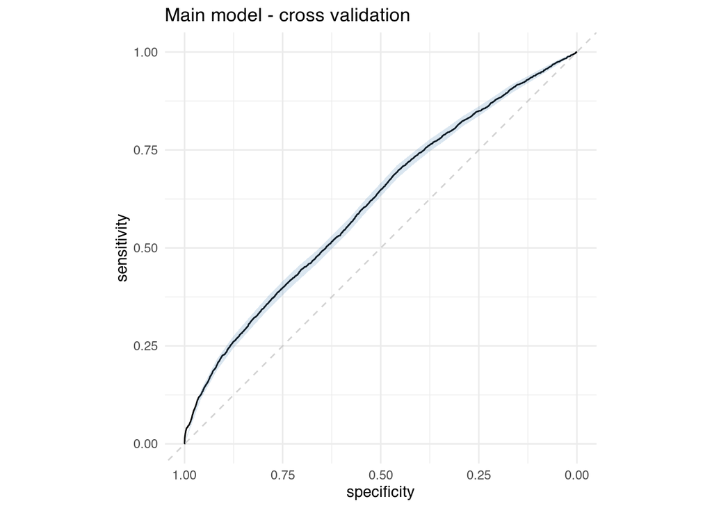

```r
# ROC curve with confidence interval
temporary$roc_plot
```

```r
# ROC-AUC
temporary$auc
```

```
## Area under the curve: 0.6121
```

```r
# ROC-AUC confidence interval
temporary$auc_ci
```

```
## 95% CI: 0.6016-0.6225 (DeLong)
```

#### Brier score

```r
temporary<-compute_brier(cv_roc)
```

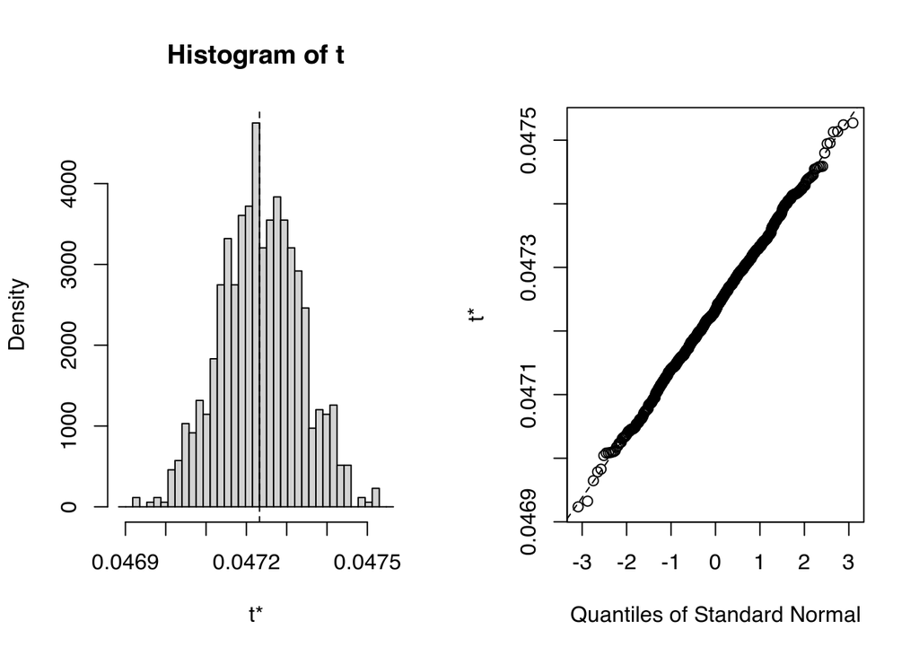

```r
## Brier score
temporary$Brier_score
```

```
## [1] 0.04723258
```

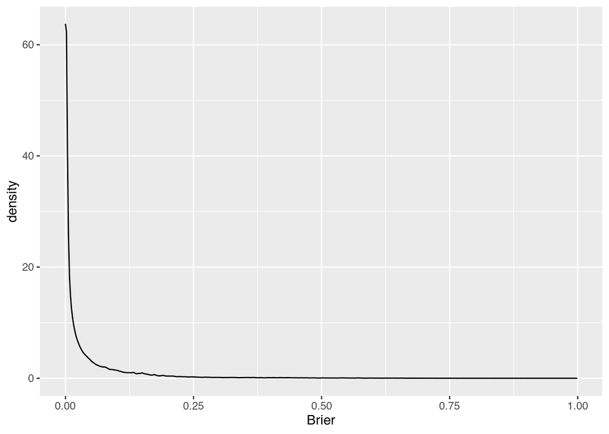

```r
### Check distribution of Brier scores
temporary$Brier_score_dist
```

```r
### Bootstrap confidence interval for Brier score
temporary$Brier_bootstrap_trainset
```

```
##
## ORDINARY NONPARAMETRIC BOOTSTRAP
##
##
## Call:
## boot(data = input_data$Brier, statistic = Boot_mean, R = 1000)
##
##
## Bootstrap Statistics :
##       original      bias     std. error
## t1* 0.04723258 2.98965e-06 9.906704e-05
```

```r
temporary$Brier_ci
```

```
## BOOTSTRAP CONFIDENCE INTERVAL CALCULATIONS
## Based on 1000 bootstrap replicates
##
## CALL :
## boot.ci(boot.out = results_train, conf = 0.95, type = c("norm",
##     "basic", "perc"))
##
## Intervals :
## Level      Normal              Basic              Percentile
## 95%   ( 0.0470,  0.0474 )   ( 0.0470,  0.0474 )   ( 0.0470,  0.0474 )
## Calculations and Intervals on Original Scale
```

### Calibration plot

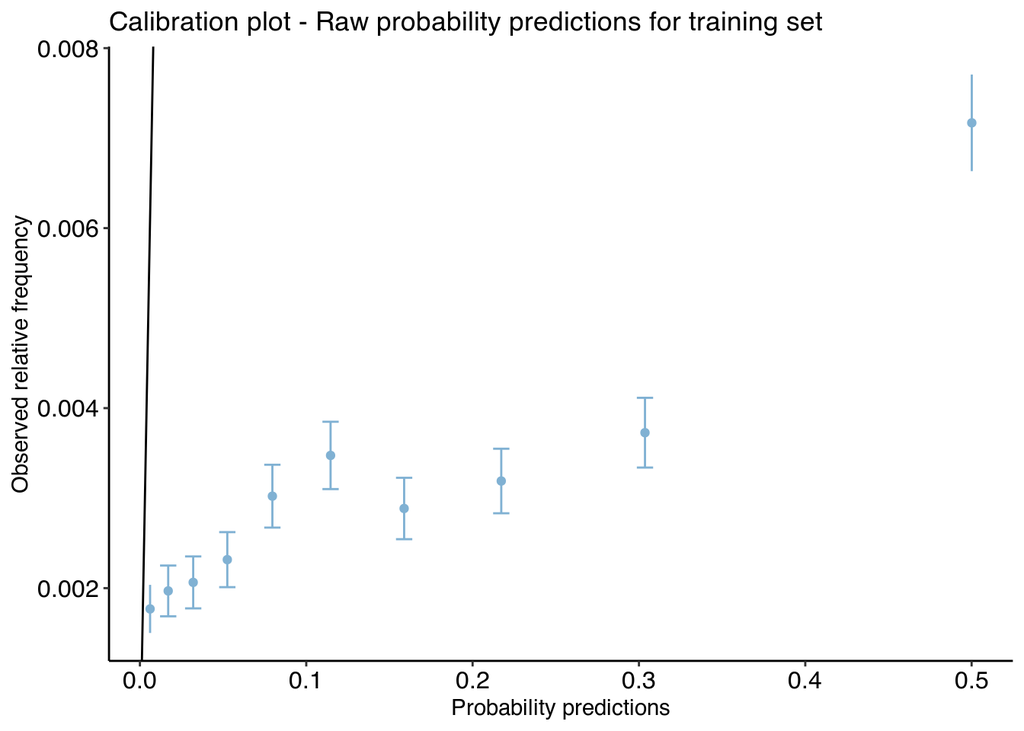

```r
temporary<-generate_calibration_plot(input_data = cv_roc,recalibration_data = data_training)
# Calibration plot for raw probability predictions
temporary[["calibration"]]
```

```r
## Check
temporary[["recalibration_check"]]
```

```
## [1] 0
```

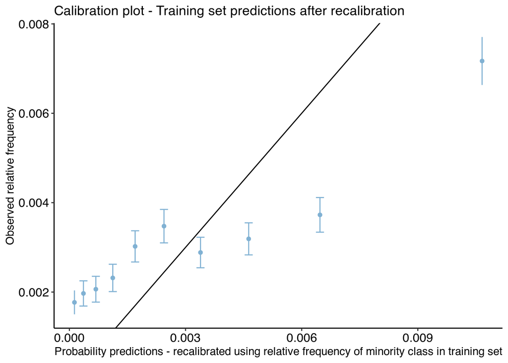

```r
# Calibration plot after recalibration
temporary[["recalibrated_calibration"]]
```

#### Discimination - Violin plot

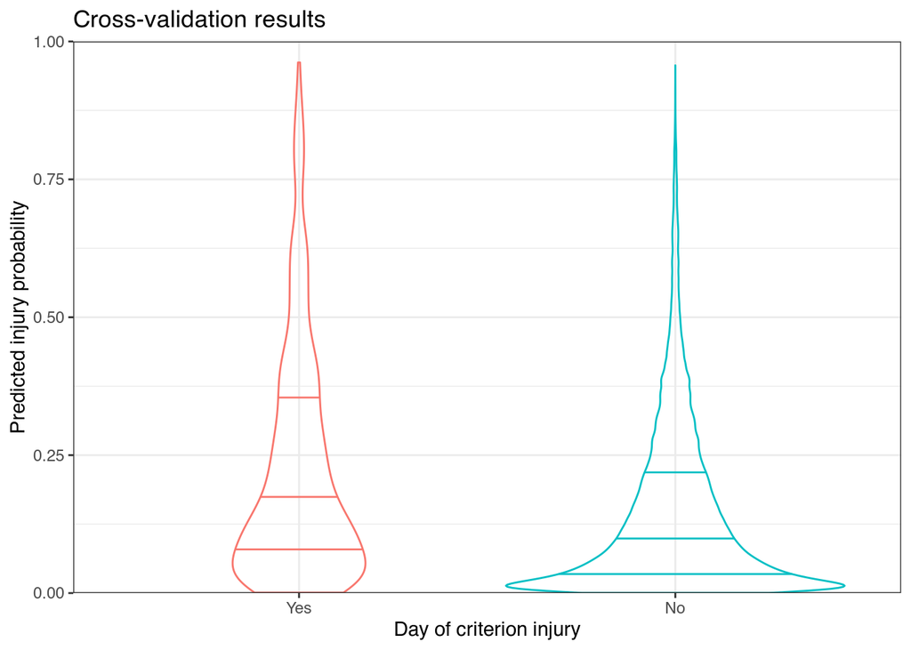

```r
violin_plot(cv_roc)
```

### Feature importance

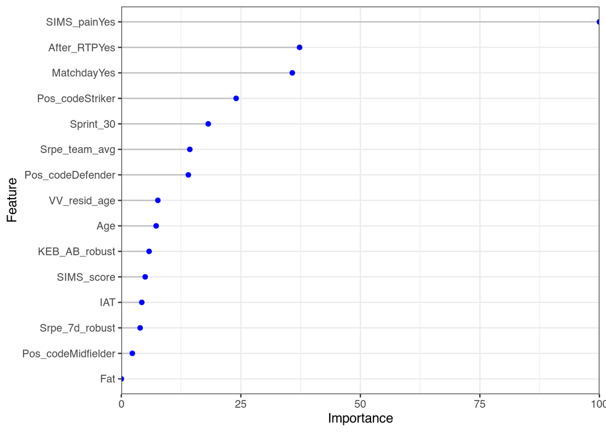

```r
plot_varimp(gbm_tree_auto)
```

### Get testset predictions

```r
# Apply to test set
Predicted_1 <- predict(gbm_tree_auto, newdata=data_test)

# View predictions for the test set
Predicted_1b <- data.frame(Predicted_1)

# Merge with testset
data_test_plus <- cbind(data_test, Predicted_1b)
data_test_plus$Predicted_1 <- factor(data_test_plus$Predicted_1, levels = c("No", "Yes"))

# Check confusion matrix
table(data_test_plus$Crit, data_test_plus$Predicted_1)
```

```
##
##         No  Yes
##   No  4535    8
##   Yes   11    0
```

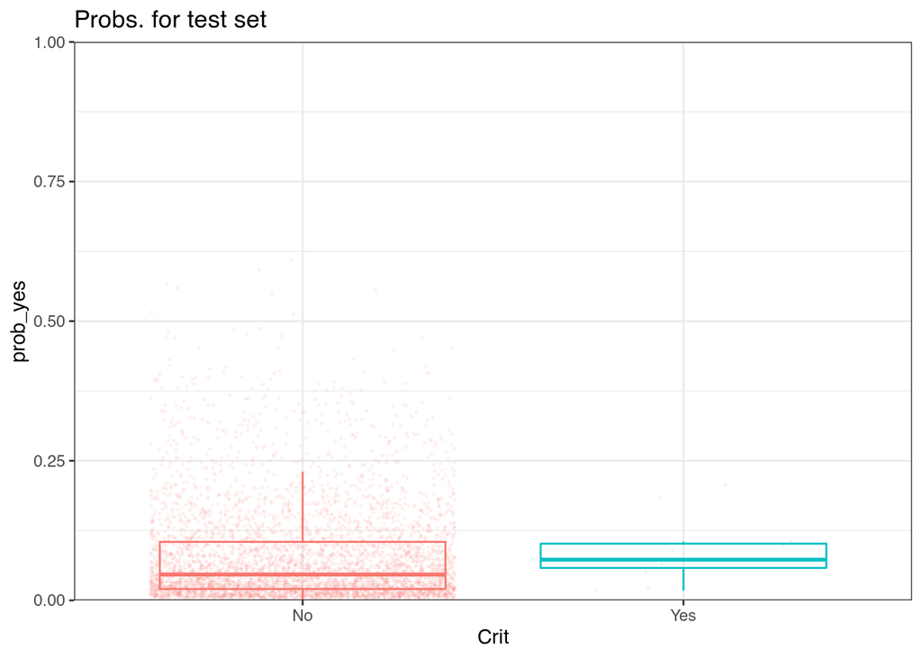

```r
# Get probabilities
Predicted_1p <- predict(gbm_tree_auto, newdata=data_test, type = "prob")
colnames(Predicted_1p) <- c("prob_no", "prob_yes")

# Merge
data_test_plus <- cbind(data_test_plus, Predicted_1p)
data_test_plus$Predicted <- factor(data_test_plus$Predicted, levels = c("No", "Yes"))

# Plot
ggplot(data_test_plus, aes(x=Crit, y=prob_yes, color = Crit))+ geom_jitter(alpha=0.1,size=0.6,shape=16)+ geom_boxplot(outlier.shape = NA,fill=NA)   + ggtitle("Probs. for test set")+guides(color="none")+ggplot_theme+scale_y_continuous(expand=c(0,0),limits = c(0,1))
```

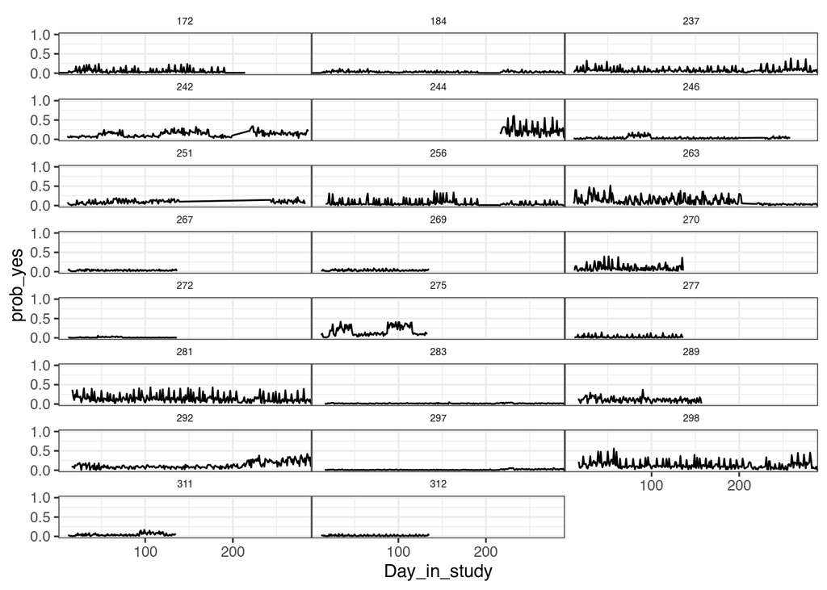

```r
ggplot(data_test_plus, aes(x=Day_in_study, y=prob_yes) ) + geom_line() +facet_wrap(~ID,ncol = 3) +scale_y_continuous(limits = c(0,1),breaks = c(0,0.5,1))+ggplot_theme+theme(strip.background = element_blank(),strip.text = element_text(size=6),panel.spacing = unit(0, "lines"))+scale_x_continuous(expand=c(0,0))
```

## Testset performance

### ROC curve

```r
temporary<-generate_rocs(data_test_plus)
```

```
## Progress disabled when using parallel plyr
```

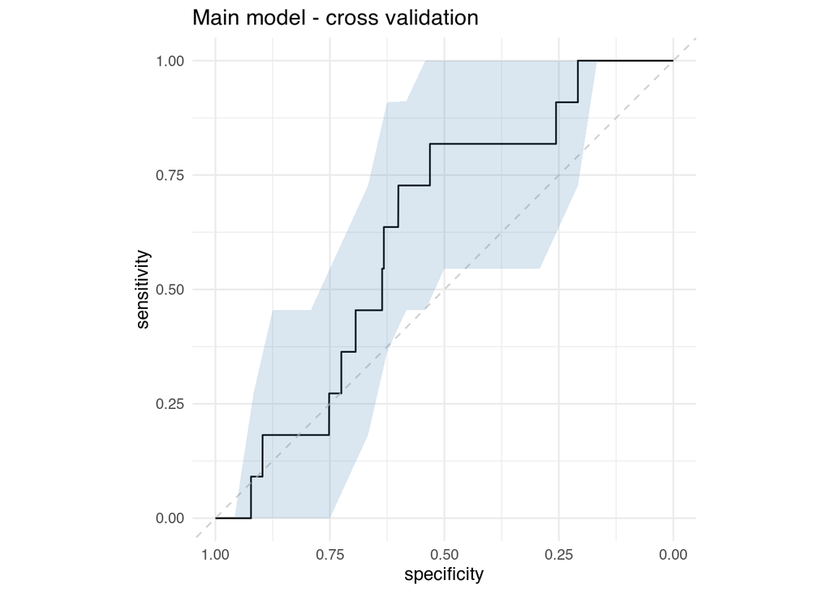

```r
# ROC curve with confidence interval
temporary$roc_plot
```

```r
# ROC-AUC
temporary$auc
```

```
## Area under the curve: 0.6232
```

```r
# ROC-AUC confidence interval
temporary$auc_ci
```

```
## 95% CI: 0.4891-0.7573 (DeLong)
```

### Brier score

```r
data_test_plus$CritL <- data_test_plus$Crit == "Yes"
data_test_plus$CritL <- as.numeric(data_test_plus$CritL)


temporary<-compute_brier(data_test_plus)
```

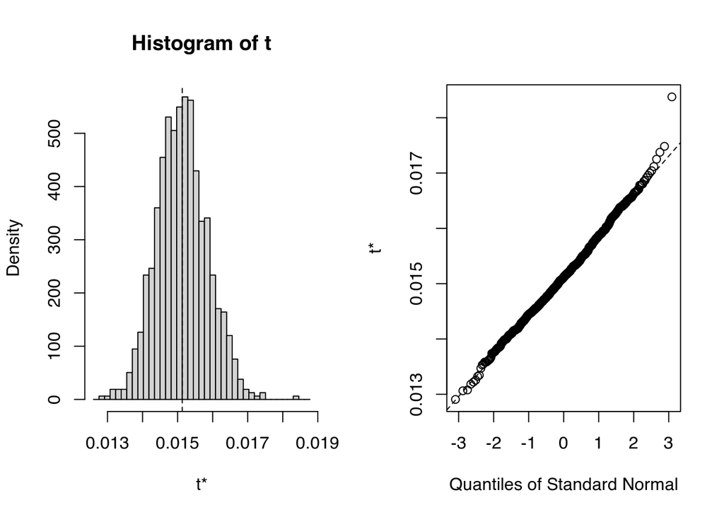

```r
## Brier score
temporary$Brier_score
```

```
## [1] 0.01513323
```

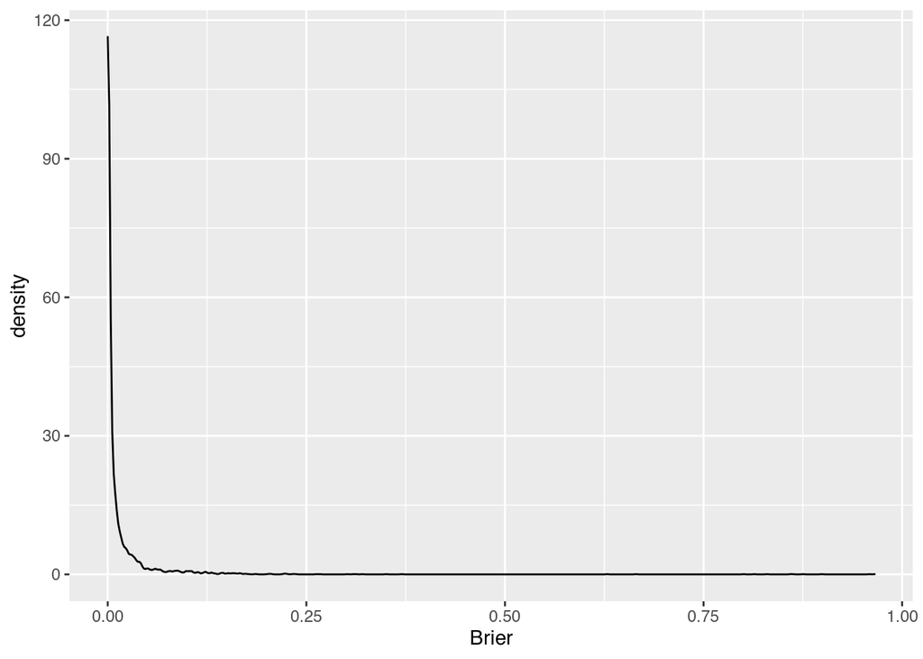

```r
### Check distribution of Brier scores
temporary$Brier_score_dist
```

```r
### Bootstrap confidence interval for Brier score
temporary$Brier_bootstrap_trainset
```

```
##
## ORDINARY NONPARAMETRIC BOOTSTRAP
##
##
## Call:
## boot(data = input_data$Brier, statistic = Boot_mean, R = 1000)
##
##
## Bootstrap Statistics :
##       original       bias     std. error
## t1* 0.01513323 3.574079e-07 0.0007241094
```

```r
temporary$Brier_ci
```

```
## BOOTSTRAP CONFIDENCE INTERVAL CALCULATIONS
## Based on 1000 bootstrap replicates
##
## CALL :
## boot.ci(boot.out = results_train, conf = 0.95, type = c("norm",
##     "basic", "perc"))
##
## Intervals :
## Level      Normal              Basic              Percentile
## 95%   ( 0.0137,  0.0166 )   ( 0.0137,  0.0165 )   ( 0.0138,  0.0166 )
## Calculations and Intervals on Original Scale
```

### Calibration plot

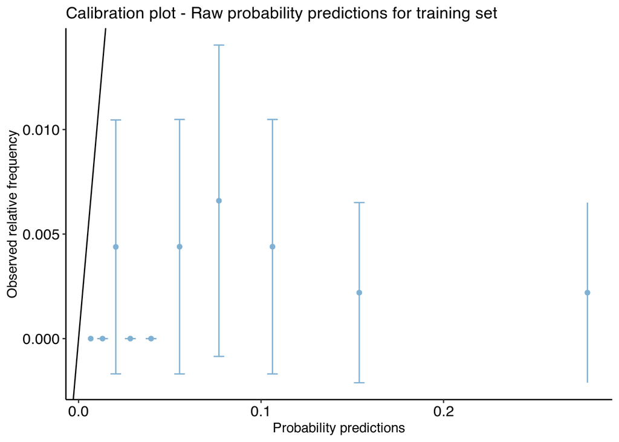

```r
temporary<-generate_calibration_plot(input_data = data_test_plus,recalibration_data = data_training)
# Calibration plot for raw probability predictions
temporary[["calibration"]]
```

```r
## Check
temporary[["recalibration_check"]]
```

```
## [1] 0
```

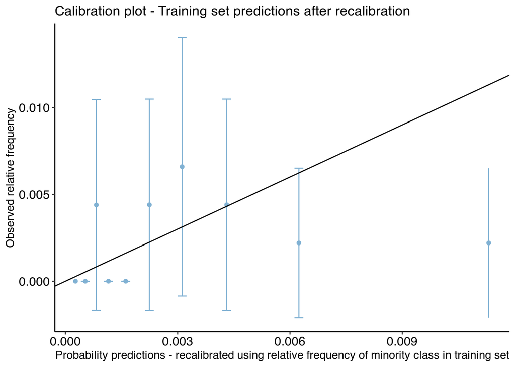

```r
# Calibration plot after recalibration
temporary[["recalibrated_calibration"]]
```

#### Discimination - Violin plot

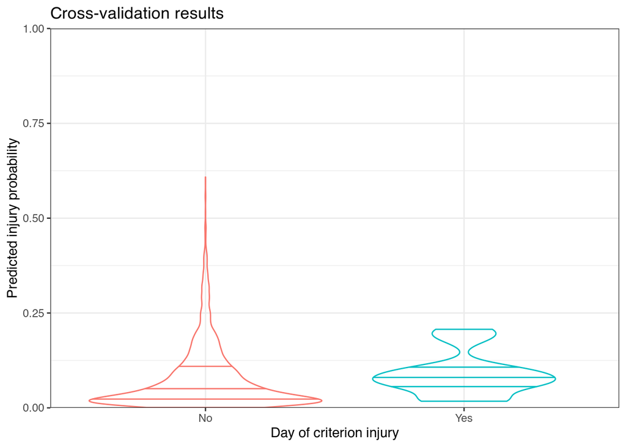

```r
violin_plot(data_test_plus)
```

### Predictions on the training set

Predictions are made with the original (non-upsampled) training set

```r
# ROC curve training set
## Make predictions with initial (not upsampled) training set
Predicted_train_1 <- predict(gbm_tree_auto, newdata=data_training)

## View predictions for the training set
Predicted_train_1b <- data.frame(Predicted_train_1)

## Merge with trainingset
data_train_plus <- cbind(data_training, Predicted_train_1b)
data_train_plus$Predicted_train_1 <- factor(data_train_plus$Predicted_train_1, levels = c("No", "Yes"))

## Check confusion matrix
table(data_train_plus$Crit, data_train_plus$Predicted_train_1)
```

```
##
##          No   Yes
##   No  12581    43
##   Yes    36     4
```

```r
## Get probabilities
Predicted_train_1p <- predict(gbm_tree_auto, newdata=data_training, type = "prob")
colnames(Predicted_train_1p) <- c("prob_no", "prob_yes")

## Merge
data_train_plus <- cbind(data_train_plus, Predicted_train_1p)
```

### Training set performance

#### ROC curve

```r
temporary<-generate_rocs(data_train_plus)
```

```
## Progress disabled when using parallel plyr
```

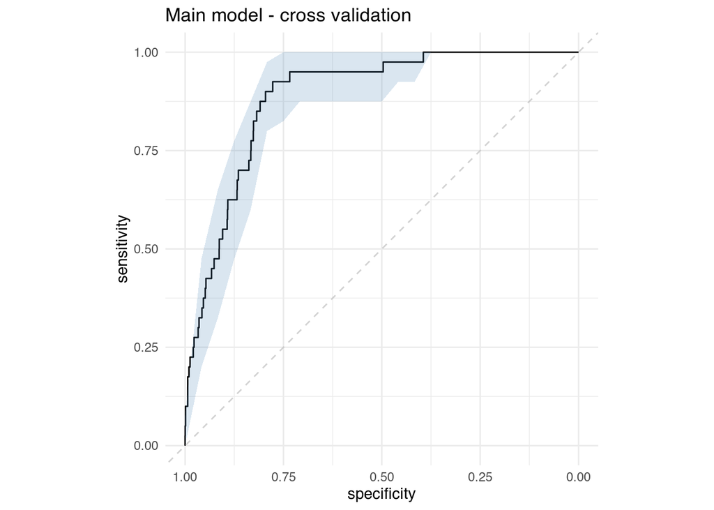

```r
# ROC curve with confidence interval
temporary$roc_plot
```

```r
# ROC-AUC
temporary$auc
```

```
## Area under the curve: 0.8874
```

```r
# ROC-AUC confidence interval
temporary$auc_ci
```

```
## 95% CI: 0.8481-0.9268 (DeLong)
```

#### Brier score

```r
data_train_plus$CritL <- data_train_plus$Crit == "Yes"
data_train_plus$CritL <- as.numeric(data_train_plus$CritL)

temporary<-compute_brier(data_train_plus)
```

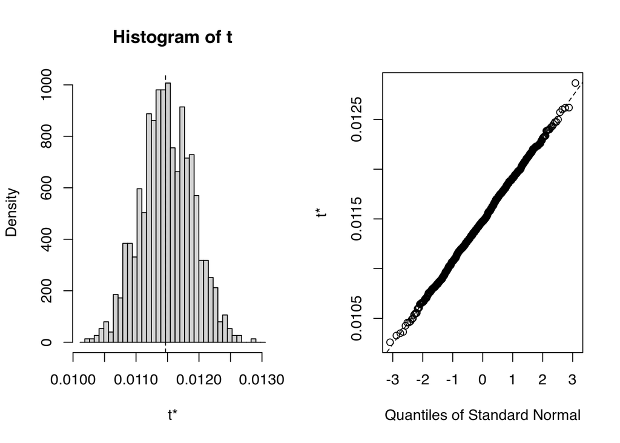

```r
## Brier score
temporary$Brier_score
```

```
## [1] 0.01146948
```

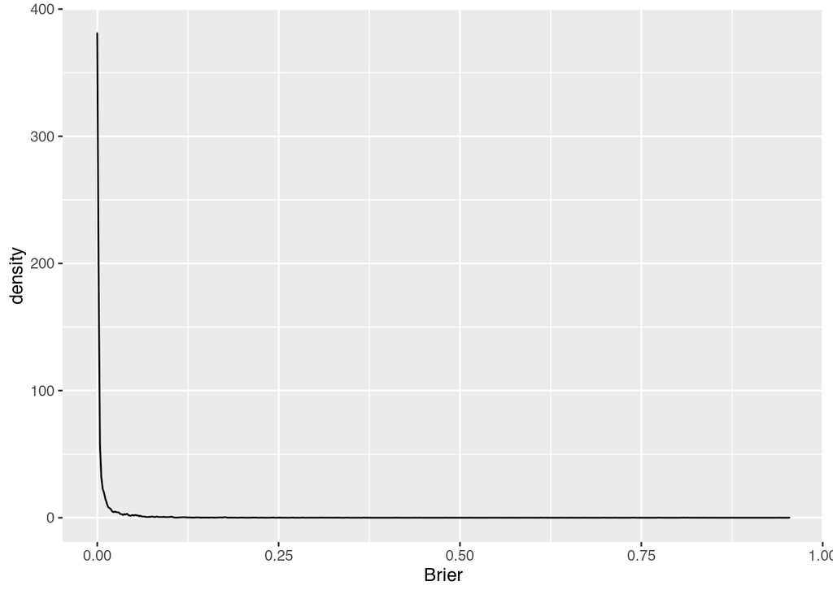

```r
### Check distribution of Brier scores
temporary$Brier_score_dist
```

```r
### Bootstrap confidence interval for Brier score
temporary$Brier_bootstrap_trainset
```

```
##
## ORDINARY NONPARAMETRIC BOOTSTRAP
##
##
## Call:
## boot(data = input_data$Brier, statistic = Boot_mean, R = 1000)
##
##
## Bootstrap Statistics :
##       original       bias     std. error
## t1* 0.01146948 1.901216e-05 0.0004156521
```

```r
temporary$Brier_ci
```

```
## BOOTSTRAP CONFIDENCE INTERVAL CALCULATIONS
## Based on 1000 bootstrap replicates
##
## CALL :
## boot.ci(boot.out = results_train, conf = 0.95, type = c("norm",
##     "basic", "perc"))
##
## Intervals :
## Level      Normal              Basic              Percentile
## 95%   ( 0.0106,  0.0123 )   ( 0.0107,  0.0123 )   ( 0.0107,  0.0123 )
## Calculations and Intervals on Original Scale
```

#### Calibration plot

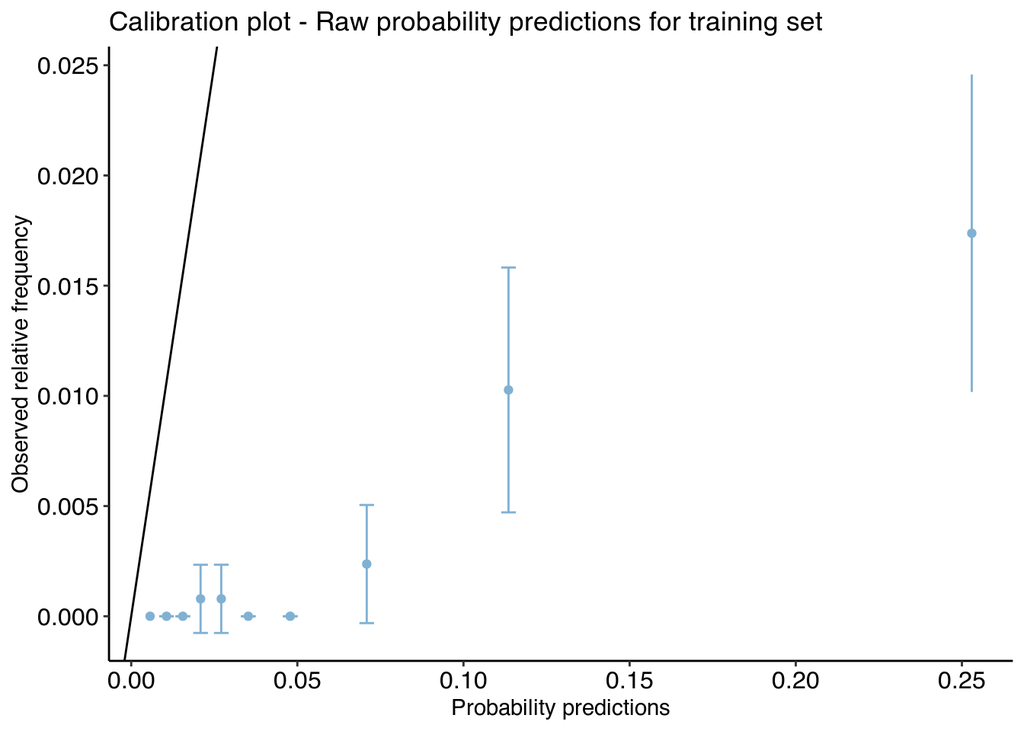

```r
temporary<-generate_calibration_plot(input_data = data_train_plus,recalibration_data = data_training)
# Calibration plot for raw probability predictions
temporary[["calibration"]]
```

```r
## Check
temporary[["recalibration_check"]]
```

```
## [1] 0
```

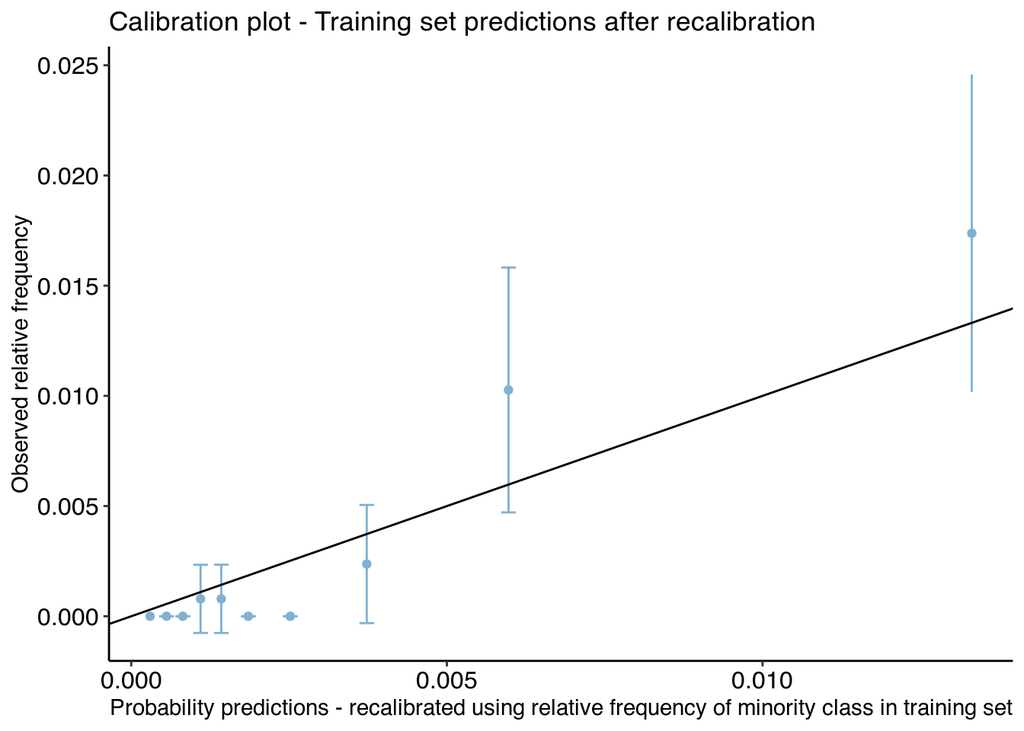

```r
# Calibration plot after recalibration
temporary[["recalibrated_calibration"]]
```

#### Discimination - Violin plot

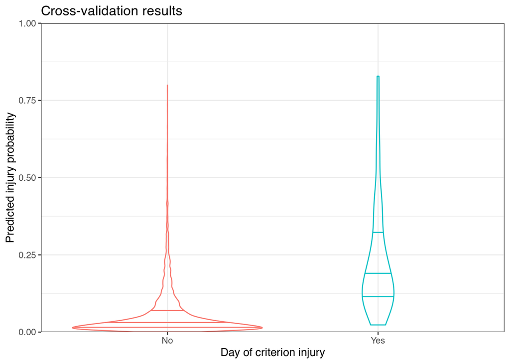

```r
violin_plot(data_train_plus)
```

```r
#End Parallel Computation
stopCluster(cl)
registerDoSEQ()
```